# R- Assignment7

Payton Kim

10/16/2019

```r
library(tidyverse)
library(readxl)
library(dplyr)
library(gganimate)
library(stringr)
library(gifski)
library(png)
```

1. Write a function: input a number x and return x^2 + 3x + 1

```r
func <- function(x) {x^2 + 3*x + 1}
func(5)
```

```
## [1] 41
```

2. 2. Not using loops, write a function: input a vector and return the product of all the entries in the vector.

```r
vec <- c(1,2,3,4,5,6)
func <- function(x) {prod(x)}
func(vec)
```

```
## [1] 720
```

3. Using loops, write a function: input a vector and return the product of all the entries in the vector

```r
vec <- c(2,3,4,5)
product <- 1
func <- function(x) {
  for(i in vec) {
    product <- i * product
  }
  product
}
func(vec)
```

```
## [1] 120
```

4. Use the above approach to write to caculate or plot • (a) the rows sum squares of matrix x above. • (b) the row sums of positive entries in y, where y is a 100x100 matrix with the entries following standard normal distribution. • (c) the row sums square of entries in y, where y is a 100x100 matrix with the entries following standard normal distribution. What is the distribution of these sum squares? • (d) the historgrams for each rows in z, where z is a 3x1000 matrix with the entries following standard normal distribution.

```r
#a.
a = matrix(c(1:9), nrow = 3)
a
```

```
##      [,1] [,2] [,3]
## [1,]    1    4    7
## [2,]    2    5    8
## [3,]    3    6    9
```

```r
apply(a, 1, function(w){sum(w^2)})
```

```
## [1]  66  93 126
```

```r
#b
y = matrix(rnorm(10000,mean = 0, sd = 1), nrow = 100)
func <- function(w) {
  sum(w[which(w>0)])
}
apply(y, 1, func)
```

```
##   [1] 37.32592 31.22464 41.50967 42.40133 48.96555 49.56424 47.09409
##   [8] 40.11219 50.64613 30.01815 38.91982 47.44935 39.70554 40.99680
##  [15] 42.03876 49.61193 36.30836 34.26182 44.34571 46.67564 34.89244
##  [22] 37.31330 30.64317 49.73602 27.72695 40.00625 35.22554 37.06749
##  [29] 42.89186 49.16539 35.16111 31.71755 35.63259 39.09006 34.15798
##  [36] 36.36816 38.64953 37.91591 36.98827 34.09875 38.92856 50.03794
##  [43] 45.38193 33.30751 33.77606 30.92698 40.15839 44.22896 41.68720
##  [50] 46.43929 37.22643 37.44308 41.92085 36.72115 45.49096 38.77152
##  [57] 41.18841 48.66193 40.17316 35.09329 38.45315 30.90261 29.58616
##  [64] 49.96460 43.65436 42.43500 38.18458 32.29801 40.20252 37.51391
##  [71] 46.35025 45.43789 39.27110 40.73275 37.55031 46.35641 45.99646
##  [78] 31.82448 32.21809 43.07203 38.36235 37.94668 38.53950 38.89425
##  [85] 44.77604 32.86786 33.78920 38.42378 36.68564 31.60905 46.64472
##  [92] 45.51785 35.52843 41.58226 51.79087 46.63848 43.45692 40.31823
##  [99] 31.68300 40.88807
```

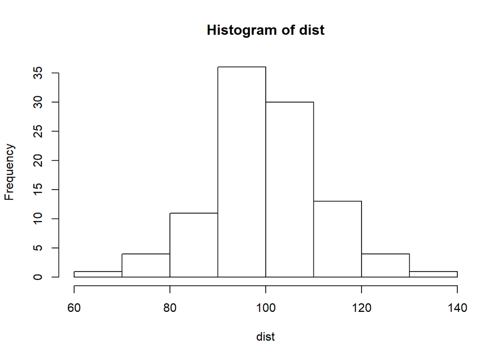

```r
#c
y = matrix(rnorm(10000,mean = 0, sd = 1), nrow = 100)
dist <- apply(y, 1, function(x) {sum(x^2)})
hist(dist)
```

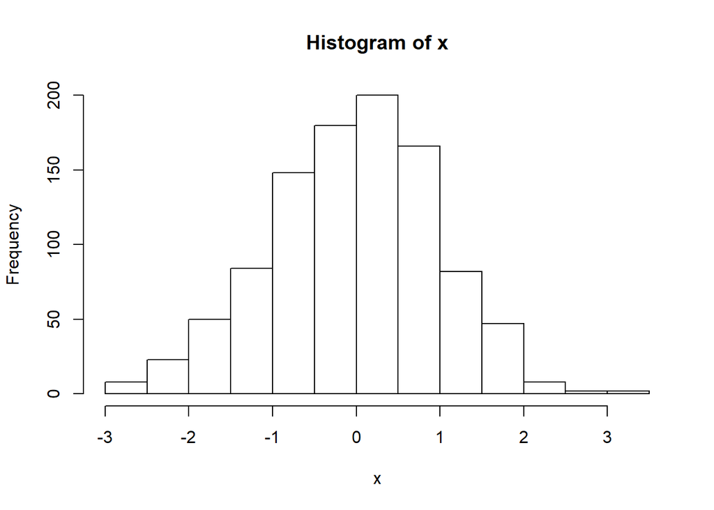

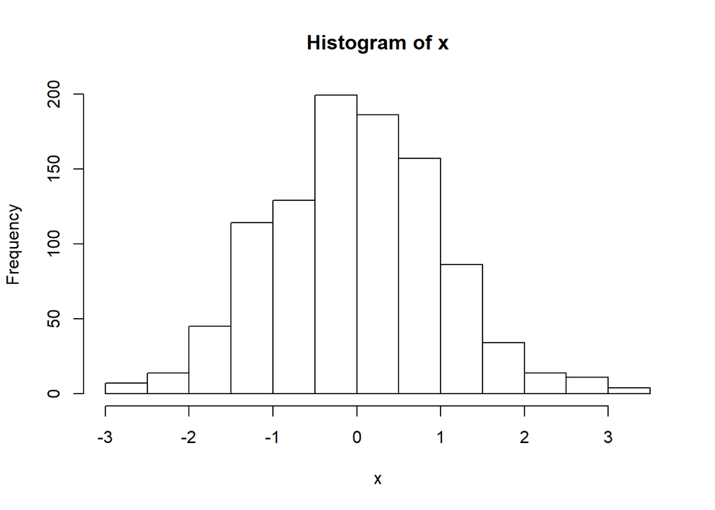

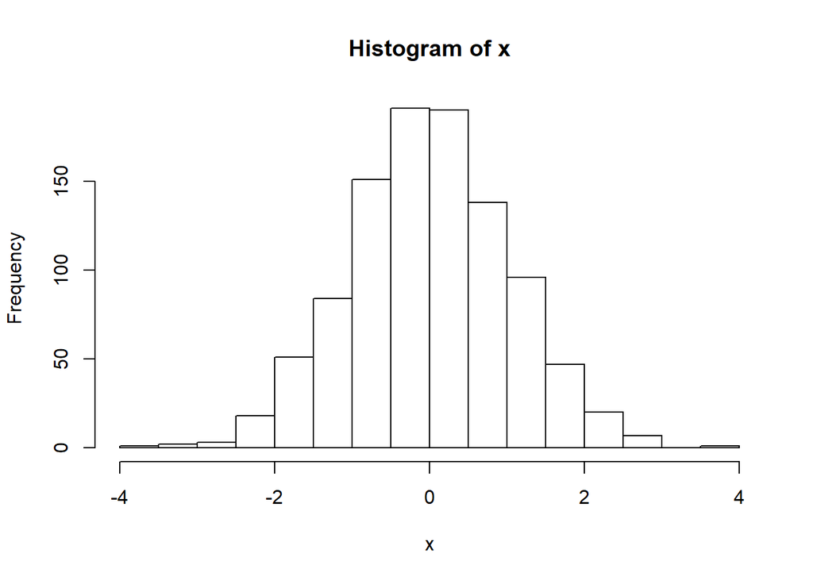

```
## [[1]]
## $breaks
##  [1] -3.0 -2.5 -2.0 -1.5 -1.0 -0.5  0.0  0.5  1.0  1.5  2.0  2.5  3.0  3.5
##
## $counts
##  [1]   8  23  50  84 148 180 200 166  82  47   8   2   2
##
## $density
##  [1] 0.016 0.046 0.100 0.168 0.296 0.360 0.400 0.332 0.164 0.094 0.016
## [12] 0.004 0.004
##
## $mids
##  [1] -2.75 -2.25 -1.75 -1.25 -0.75 -0.25  0.25  0.75  1.25  1.75  2.25
## [12]  2.75  3.25
##
## $xname
## [1] "x"
##
## $equidist
## [1] TRUE
##
## attr(,"class")
## [1] "histogram"
##
## [[2]]
## $breaks
##  [1] -3.0 -2.5 -2.0 -1.5 -1.0 -0.5  0.0  0.5  1.0  1.5  2.0  2.5  3.0  3.5
##
## $counts
##  [1]   7  14  45 114 129 199 186 157  86  34  14  11   4
##
## $density
##  [1] 0.014 0.028 0.090 0.228 0.258 0.398 0.372 0.314 0.172 0.068 0.028
## [12] 0.022 0.008
##
## $mids
##  [1] -2.75 -2.25 -1.75 -1.25 -0.75 -0.25  0.25  0.75  1.25  1.75  2.25
## [12]  2.75  3.25
##
## $xname
```

[output cut: 17 more lines]

```
##  [1] 0.002 0.004 0.006 0.036 0.102 0.168 0.302 0.382 0.380 0.276 0.192
## [12] 0.094 0.040 0.014 0.000 0.002
##
## $mids
##  [1] -3.75 -3.25 -2.75 -2.25 -1.75 -1.25 -0.75 -0.25  0.25  0.75  1.25
## [12]  1.75  2.25  2.75  3.25  3.75
##
## $xname
## [1] "x"
##
## $equidist
## [1] TRUE
##
## attr(,"class")
## [1] "histogram"
```

```r
#This looks like a chi-sqaured distribution

#d
z = matrix(rnorm(3000, mean = 0, sd = 1), nrow = 3)
apply(z, 1, function(x) {hist(x)})
```

5. Write a function: • input a vector v and a value n • out the original vector with its missing data in v being replaced by n. v could be a numeric or characrer vector and n could be a number or a string. If there is no missing value, return v and the message There is no missing value.

```r
numbers <- c(1,2,NA,4)
replace <- 5
vect <- function(v, n) {
  if(sum(is.na(v)) == 0) {
    print("There is no missing valu.")}
    else {
      v[is.na(v)] <- n
      print(v)}
}
vect(numbers, replace)
```

```
## [1] 1 2 5 4
```

6. Write a function: • input a numeric vector • output the original vector with its missing data being replaced by the mean of the vector. If there is no missing value, return the original vector with the message There is no missing value.

```r
vec <- c(1,2,3,NA,5)
avg <- mean(vec, na.rm = TRUE)

repl <- function(vec, avg) {
  if(sum(is.na(vec)) == 0) {
    print("There is no missing value.")}
  else {
    vec[is.na(vec)] <- avg
    print(vec)
  }
   }
repl(vec, avg)
```

```
## [1] 1.00 2.00 3.00 2.75 5.00
```

7. Write a function: • input a character/factor vector • output a vector with its missing data being replaced by the mode of the vector. If there is no missing value, return the original vector with the message “There is no missing value.”

```r
w <- c("it", "the", NA, "the", "is")
un <- unique(w)

wmode <- function(w) {
  if(sum(is.na(w)) == 0) {
    print("There is no missing value.")}
  else {
    w[is.na(w)] <- un[which.max(tabulate(match(w,un)))]
    print(w)
  }
}

wmode(w)
```

```
## [1] "it"  "the" "the" "the" "is"
```

Write a function: • input a data frame • output the data frame with numeric missing values being replaced by the corresponding column mean and categorical missing values being replaced by the corresponding column mode. Check to confirm that the function woks with the titanic dataset.

```r
titanic = read_csv("C:\\Users\\student\\Downloads\\titanic.csv")
head(titanic)
```

```
## # A tibble: 6 x 12
##   PassengerId Survived Pclass Name  Sex     Age SibSp Parch Ticket  Fare
##         <dbl>    <dbl>  <dbl> <chr> <chr> <dbl> <dbl> <dbl> <chr>  <dbl>
## 1           1        0      3 Brau~ male     22     1     0 A/5 2~  7.25
## 2           2        1      1 Cumi~ fema~    38     1     0 PC 17~ 71.3
## 3           3        1      3 Heik~ fema~    26     0     0 STON/~  7.92
## 4           4        1      1 Futr~ fema~    35     1     0 113803 53.1
## 5           5        0      3 Alle~ male     35     0     0 373450  8.05
## 6           6        0      3 Mora~ male     NA     0     0 330877  8.46
## # ... with 2 more variables: Cabin <chr>, Embarked <chr>
```

```r
glimpse(titanic)
```

```
## Observations: 891
## Variables: 12
## $ PassengerId <dbl> 1, 2, 3, 4, 5, 6, 7, 8, 9, 10, 11, 12, 13, 14, 15,...
## $ Survived    <dbl> 0, 1, 1, 1, 0, 0, 0, 0, 1, 1, 1, 1, 0, 0, 0, 1, 0,...
## $ Pclass      <dbl> 3, 1, 3, 1, 3, 3, 1, 3, 3, 2, 3, 1, 3, 3, 3, 2, 3,...
## $ Name        <chr> "Braund, Mr. Owen Harris", "Cumings, Mrs. John Bra...
## $ Sex         <chr> "male", "female", "female", "female", "male", "mal...
## $ Age         <dbl> 22, 38, 26, 35, 35, NA, 54, 2, 27, 14, 4, 58, 20, ...
## $ SibSp       <dbl> 1, 1, 0, 1, 0, 0, 0, 3, 0, 1, 1, 0, 0, 1, 0, 0, 4,...
## $ Parch       <dbl> 0, 0, 0, 0, 0, 0, 0, 1, 2, 0, 1, 0, 0, 5, 0, 0, 1,...
## $ Ticket      <chr> "A/5 21171", "PC 17599", "STON/O2. 3101282", "1138...
## $ Fare        <dbl> 7.2500, 71.2833, 7.9250, 53.1000, 8.0500, 8.4583, ...
## $ Cabin       <chr> NA, "C85", NA, "C123", NA, NA, "E46", NA, NA, NA, ...
## $ Embarked    <chr> "S", "C", "S", "S", "S", "Q", "S", "S", "S", "C", ...
```

```r
sum(is.na(titanic[,6]))
```

```
## [1] 177
```

```r
sum(is.na(titanic[,12]))
```

```
## [1] 2
```

```r
onecnum <- function(x) {
 x[,6][is.na(x[,6])] <- colMeans(x[,6], na.rm = TRUE)
  print(x[,6])
}

onecchar <- function(x) {
  un <- unique(x[,12])
  x[,12][is.na(x[,12])] <- as.character(unique(x[,12])[which.max(tabulate(match(x[,12],unique(x[,12]))))])
  print(x[,12])
}
onecnum(titanic)
```

```
## # A tibble: 891 x 1
##      Age
##    <dbl>
##  1  22
##  2  38
##  3  26
##  4  35
##  5  35
##  6  29.7
##  7  54
##  8   2
##  9  27
## 10  14
## # ... with 881 more rows
```

```r
onecchar(titanic)
```

```
## # A tibble: 891 x 1
##    Embarked
##    <chr>
##  1 S
##  2 C
##  3 S
##  4 S
##  5 S
##  6 Q
##  7 S
##  8 S
##  9 S
## 10 C
## # ... with 881 more rows
```

```r
as.character(unique(titanic[,12])[which.max(tabulate(match(titanic[,12],unique(titanic[,12]))))])
```

```
## [1] "c(\"S\", \"C\", \"Q\", NA)"
```

```r
sum(is.na(onecnum(titanic)))
```

```
## # A tibble: 891 x 1
##      Age
##    <dbl>
##  1  22
##  2  38
##  3  26
##  4  35
##  5  35
##  6  29.7
##  7  54
##  8   2
##  9  27
## 10  14
## # ... with 881 more rows
```

```
## [1] 0
```

```r
sum(is.na(onecchar(titanic)))
```

```
## # A tibble: 891 x 1
##    Embarked
##    <chr>
##  1 S
##  2 C
##  3 S
##  4 S
##  5 S
##  6 Q
##  7 S
##  8 S
##  9 S
## 10 C
## # ... with 881 more rows
```

```
## [1] 0
```

9. Write a function that • input two categorical variables • output the bar chart of one variable color filled by the other variable. Check your function with two categorical variables in the titanic data